# Project: TMDB Movies Dataset

- Introduction
- Data Wrangling
- Exploratory Data Analysis
- Conclusions

## Introduction

This dataset contains information about 10,000 movies collected from The Movie Database (TMDb), including user ratings and revenue, etc. the original datset can be downloaded from [Kaggle](https://www.kaggle.com/tmdb/tmdb-movie-metadata).

**Target**: In this projest I'm going to investigate and analyse TMDb movie dataset to explore how to evaluate a successful movie, and what is the most important factors

> The data you will use for this analysis can be accessed here: "data/tmdb-movies.csv"

## Required Tools

| Library | Description |
| --- | --- |
| [numpy](https://numpy.org) | adding support for large, multi-dimensional arrays and matrices |
| [pandas](https://pandas.pydata.org) | for data manipulation and analysis. |
| [matplotlib](https://matplotlib.org) & [seaborn](https://seaborn.pydata.org) | is a plotting library for data visualization |

## Dataset

the data contains about 10000 observasion, and the following columns:

- movie_id: Integer, A unique identifier for each movie.
- imdb_id: Char, A unique identifier for each movie on IMDB.
- cast: List, The name of lead and supporting actors.
- director: Char, the director of the movie
- budget: Numeric, The budget in which the movie was made.
- genre: List, The genre of the movie, Action, Comedy ,Thriller etc.
- homepage: Char, A link to the homepage of the movie.
- keywords: List, The keywords or tags related to the movie.
- original_title: Char, The title of the movie before translation or adaptation.
- overview: Char, A brief description of the movie.
- popularity: Numeric, A numeric quantity specifying the movie popularity.
- production_companies: Char, The production house of the movie.
- release_date: Date, The date on which it was released.
- revenue: Numeric, The worldwide revenue generated by the movie.
- runtime: Integer, The running time of the movie in minutes.
- tagline: Char, Movie's tagline.
- vote_average: Numeric, average ratings the movie recieved.
- budget_adj: Numeric, shows the budget associated movie in terms of 2010 dollars.
- revenue_adj: Numeric, shows the revenue associated movie in terms of 2010 dollars.

## Analysis Plan

after exploring the fields in the dataset we conduct This analysis plan which to answer the following questions.

1. Which genres are most popular from year to year?
2. what is the factors of high revenue ?
3. What is the Charectistic of top movies

```python
# Use this cell to set up import statements for all of the packages that you
#   plan to use.

# Remember to include a 'magic word' so that your visualizations are plotted
#   inline with the notebook. See this page for more:
#   http://ipython.readthedocs.io/en/stable/interactive/magics.html
import pandas as pd
import numpy as np
import matplotlib.pyplot as plt
import seaborn as sns
# set seaborn figures by defualt
%matplotlib inline
sns.set()
```

## Data Wrangling

> **Tip**: In this section of the report, you will load in the data, check for cleanliness, and then trim and clean your dataset for analysis. Make sure that you document your steps carefully and justify your cleaning decisions.

### General Properties

```python
# Load your data and print out a few lines. Perform operations to inspect data
#   types and look for instances of missing or possibly errant data.
df = pd.read_csv('data/tmdb-movies.csv')

df.head()
```

|  | id | imdb_id | popularity | budget | revenue | original_title | cast | homepage | director | tagline | ... | overview | runtime | genres | production_companies | release_date | vote_count | vote_average | release_year | budget_adj | revenue_adj |
| --- | --- | --- | --- | --- | --- | --- | --- | --- | --- | --- | --- | --- | --- | --- | --- | --- | --- | --- | --- | --- | --- |
| 0 | 135397 | tt0369610 | 32.985763 | 150000000 | 1513528810 | Jurassic World | Chris Pratt\|Bryce Dallas Howard\|Irrfan Khan\|Vi... | http://www.jurassicworld.com/ | Colin Trevorrow | The park is open. | ... | Twenty-two years after the events of Jurassic ... | 124 | Action\|Adventure\|Science Fiction\|Thriller | Universal Studios\|Amblin Entertainment\|Legenda... | 6/9/15 | 5562 | 6.5 | 2015 | 1.379999e+08 | 1.392446e+09 |
| 1 | 76341 | tt1392190 | 28.419936 | 150000000 | 378436354 | Mad Max: Fury Road | Tom Hardy\|Charlize Theron\|Hugh Keays-Byrne\|Nic... | http://www.madmaxmovie.com/ | George Miller | What a Lovely Day. | ... | An apocalyptic story set in the furthest reach... | 120 | Action\|Adventure\|Science Fiction\|Thriller | Village Roadshow Pictures\|Kennedy Miller Produ... | 5/13/15 | 6185 | 7.1 | 2015 | 1.379999e+08 | 3.481613e+08 |
| 2 | 262500 | tt2908446 | 13.112507 | 110000000 | 295238201 | Insurgent | Shailene Woodley\|Theo James\|Kate Winslet\|Ansel... | http://www.thedivergentseries.movie/#insurgent | Robert Schwentke | One Choice Can Destroy You | ... | Beatrice Prior must confront her inner demons ... | 119 | Adventure\|Science Fiction\|Thriller | Summit Entertainment\|Mandeville Films\|Red Wago... | 3/18/15 | 2480 | 6.3 | 2015 | 1.012000e+08 | 2.716190e+08 |
| 3 | 140607 | tt2488496 | 11.173104 | 200000000 | 2068178225 | Star Wars: The Force Awakens | Harrison Ford\|Mark Hamill\|Carrie Fisher\|Adam D... | http://www.starwars.com/films/star-wars-episod... | J.J. Abrams | Every generation has a story. | ... | Thirty years after defeating the Galactic Empi... | 136 | Action\|Adventure\|Science Fiction\|Fantasy | Lucasfilm\|Truenorth Productions\|Bad Robot | 12/15/15 | 5292 | 7.5 | 2015 | 1.839999e+08 | 1.902723e+09 |
| 4 | 168259 | tt2820852 | 9.335014 | 190000000 | 1506249360 | Furious 7 | Vin Diesel\|Paul Walker\|Jason Statham\|Michelle ... | http://www.furious7.com/ | James Wan | Vengeance Hits Home | ... | Deckard Shaw seeks revenge against Dominic Tor... | 137 | Action\|Crime\|Thriller | Universal Pictures\|Original Film\|Media Rights ... | 4/1/15 | 2947 | 7.3 | 2015 | 1.747999e+08 | 1.385749e+09 |

5 rows × 21 columns

```python
df.shape
```

```
(10866, 21)
```

- Data is about 10k observations and 21 columns
- Certain columns, like ‘cast’ and ‘genres’, contain multiple values separated by pipe (|) characters. we will handle this in the data pre-proccessing
- There are some odd characters in the ‘cast’ column. Don’t worry about cleaning them. You can leave them as is.
- The final two columns ending with “_adj” show the budget and revenue of the associated movie in terms of 2010 dollars, accounting for inflation over time.

```python
# explore quantitive data
df.describe(include='number')
```

|  | id | popularity | budget | revenue | runtime | vote_count | vote_average | release_year | budget_adj | revenue_adj |
| --- | --- | --- | --- | --- | --- | --- | --- | --- | --- | --- |
| count | 10866.000000 | 10866.000000 | 1.086600e+04 | 1.086600e+04 | 10866.000000 | 10866.000000 | 10866.000000 | 10866.000000 | 1.086600e+04 | 1.086600e+04 |
| mean | 66064.177434 | 0.646441 | 1.462570e+07 | 3.982332e+07 | 102.070863 | 217.389748 | 5.974922 | 2001.322658 | 1.755104e+07 | 5.136436e+07 |
| std | 92130.136561 | 1.000185 | 3.091321e+07 | 1.170035e+08 | 31.381405 | 575.619058 | 0.935142 | 12.812941 | 3.430616e+07 | 1.446325e+08 |
| min | 5.000000 | 0.000065 | 0.000000e+00 | 0.000000e+00 | 0.000000 | 10.000000 | 1.500000 | 1960.000000 | 0.000000e+00 | 0.000000e+00 |
| 25% | 10596.250000 | 0.207583 | 0.000000e+00 | 0.000000e+00 | 90.000000 | 17.000000 | 5.400000 | 1995.000000 | 0.000000e+00 | 0.000000e+00 |
| 50% | 20669.000000 | 0.383856 | 0.000000e+00 | 0.000000e+00 | 99.000000 | 38.000000 | 6.000000 | 2006.000000 | 0.000000e+00 | 0.000000e+00 |
| 75% | 75610.000000 | 0.713817 | 1.500000e+07 | 2.400000e+07 | 111.000000 | 145.750000 | 6.600000 | 2011.000000 | 2.085325e+07 | 3.369710e+07 |
| max | 417859.000000 | 32.985763 | 4.250000e+08 | 2.781506e+09 | 900.000000 | 9767.000000 | 9.200000 | 2015.000000 | 4.250000e+08 | 2.827124e+09 |

```python
# ecplore catogirical data
df.describe(include='object')
```

|  | imdb_id | original_title | cast | homepage | director | tagline | keywords | overview | genres | production_companies | release_date |
| --- | --- | --- | --- | --- | --- | --- | --- | --- | --- | --- | --- |
| count | 10856 | 10866 | 10790 | 2936 | 10822 | 8042 | 9373 | 10862 | 10843 | 9836 | 10866 |
| unique | 10855 | 10571 | 10719 | 2896 | 5067 | 7997 | 8804 | 10847 | 2039 | 7445 | 5909 |
| top | tt0411951 | Hamlet | Louis C.K. | http://www.thehungergames.movie/ | Woody Allen | Based on a true story. | woman director | No overview found. | Comedy | Paramount Pictures | 1/1/09 |
| freq | 2 | 4 | 6 | 4 | 45 | 5 | 134 | 13 | 712 | 156 | 28 |

### Data Cleaning: explore missing values

```python
# After discussing the structure of the data and any problems that need to be
#   cleaned, perform those cleaning steps in the second part of this section.
# Create data summary dictionary
Data_dict = pd.DataFrame(df.dtypes)
Data_dict = Data_dict.rename(columns = {0:'DataType'})
Data_dict['Missing Values'] = df.isnull().sum()
Data_dict['Missing Values%'] = (Data_dict['Missing Values'] / len(df)) * 100
Data_dict['Unique Values'] = df.nunique()
# display data summry dictionary
Data_dict
```

|  | DataType | Missing Values | Missing Values% | Unique Values |
| --- | --- | --- | --- | --- |
| id | int64 | 0 | 0.000000 | 10865 |
| imdb_id | object | 10 | 0.092030 | 10855 |
| popularity | float64 | 0 | 0.000000 | 10814 |
| budget | int64 | 0 | 0.000000 | 557 |
| revenue | int64 | 0 | 0.000000 | 4702 |
| original_title | object | 0 | 0.000000 | 10571 |
| cast | object | 76 | 0.699429 | 10719 |
| homepage | object | 7930 | 72.979937 | 2896 |
| director | object | 44 | 0.404933 | 5067 |
| tagline | object | 2824 | 25.989324 | 7997 |
| keywords | object | 1493 | 13.740107 | 8804 |
| overview | object | 4 | 0.036812 | 10847 |
| runtime | int64 | 0 | 0.000000 | 247 |
| genres | object | 23 | 0.211669 | 2039 |
| production_companies | object | 1030 | 9.479109 | 7445 |
| release_date | object | 0 | 0.000000 | 5909 |
| vote_count | int64 | 0 | 0.000000 | 1289 |
| vote_average | float64 | 0 | 0.000000 | 72 |
| release_year | int64 | 0 | 0.000000 | 56 |
| budget_adj | float64 | 0 | 0.000000 | 2614 |
| revenue_adj | float64 | 0 | 0.000000 | 4840 |

```python
# check zero values for quantitive data
num_cols = [col for col in df.columns if df[col].dtype != 'object']
zero_count = (df[num_cols] == 0).sum()
zero_count
```

```
id                 0
popularity         0
budget          5696
revenue         6016
runtime           31
vote_count         0
vote_average       0
release_year       0
budget_adj      5696
revenue_adj     6016
dtype: int64
```

- (budget, budject_adj, revenue, revenue_adj) have many missing values it would be better to drop them
- (runtime) have few missing values we can guess theses values by calculating the mean of movies dauration

```python
# define columns that would not be in the analysis for now
# Note: we will depend on the ('budget_adj', 'revenue_adj') in the analysis
dropped_cols = ['id', 'imdb_id', 'budget', 'revenue', 'original_title', 'homepage', 'tagline', 'overview', 'production_companies', 'keywords', 'release_date', 'vote_count']
df.drop(dropped_cols, axis=1, inplace=True)
df.rename(columns={"budget_adj": "budget", "revenue_adj": "revenue"}, inplace=True)
df.head()
```

|  | popularity | cast | director | runtime | genres | vote_average | release_year | budget | revenue |
| --- | --- | --- | --- | --- | --- | --- | --- | --- | --- |
| 0 | 32.985763 | Chris Pratt\|Bryce Dallas Howard\|Irrfan Khan\|Vi... | Colin Trevorrow | 124 | Action\|Adventure\|Science Fiction\|Thriller | 6.5 | 2015 | 1.379999e+08 | 1.392446e+09 |
| 1 | 28.419936 | Tom Hardy\|Charlize Theron\|Hugh Keays-Byrne\|Nic... | George Miller | 120 | Action\|Adventure\|Science Fiction\|Thriller | 7.1 | 2015 | 1.379999e+08 | 3.481613e+08 |
| 2 | 13.112507 | Shailene Woodley\|Theo James\|Kate Winslet\|Ansel... | Robert Schwentke | 119 | Adventure\|Science Fiction\|Thriller | 6.3 | 2015 | 1.012000e+08 | 2.716190e+08 |
| 3 | 11.173104 | Harrison Ford\|Mark Hamill\|Carrie Fisher\|Adam D... | J.J. Abrams | 136 | Action\|Adventure\|Science Fiction\|Fantasy | 7.5 | 2015 | 1.839999e+08 | 1.902723e+09 |
| 4 | 9.335014 | Vin Diesel\|Paul Walker\|Jason Statham\|Michelle ... | James Wan | 137 | Action\|Crime\|Thriller | 7.3 | 2015 | 1.747999e+08 | 1.385749e+09 |

```python
df.shape
```

```
(10866, 9)
```

```python
cols = ['cast', 'director', 'genres', 'budget', 'revenue']
df['budget'].replace(0, np.nan, inplace=True)
df['revenue'].replace(0, np.nan, inplace=True)
df['runtime'].replace(0, df['runtime'].mean(), inplace=True)
df.dropna(subset=cols, axis=0, inplace=True)
df.shape
```

```
(3850, 9)
```

### Data Cleaning: Remove Duplicates

```python
print(len(df) - len(df.drop_duplicates()))
```

```
1
```

```python
df.drop_duplicates(inplace=True)
df.shape
```

```
(3849, 9)
```

- data after filtering is about 3849 observations, 9 columns

## Exploratory Data Analysis

> **Tip**: Now that you've trimmed and cleaned your data, you're ready to move on to exploration. Compute statistics and create visualizations with the goal of addressing the research questions that you posed in the Introduction section. It is recommended that you be systematic with your approach. Look at one variable at a time, and then follow it up by looking at relationships between variables.

## Research Question 1: Which genres are most popular from year to year?

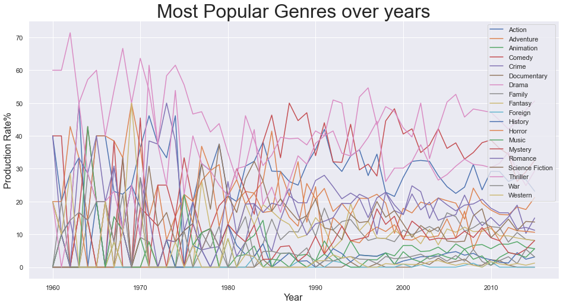

```python
# Use this, and more code cells, to explore your data. Don't forget to add
#   Markdown cells to document your observations and findings.
genre_df = df.set_index('release_year')['genres'].str.get_dummies('|')
# we won't envlove TV Movies in the comprasion because it's not a true genre
genre_df.drop('TV Movie', axis=1, inplace=True)
# plot the data as line plot
data = (genre_df.groupby('release_year').mean()) * 100
ax = data.plot(figsize=[16, 8])
ax.set_title('Most Popular Genres over years', fontsize=32)
ax.set_xlabel('Year', fontsize=16)
ax.set_ylabel('Production Rate%', fontsize=16)
```

- most popular movies are (Thriller, Comedy, Drama) at first place
- (science fiction, Music, History) have low rate compared to the others over thae time which means production companies doesn't care much about these genres

### Research Question 2: what is the factors of high revenue ?

### Budget vs Revenue

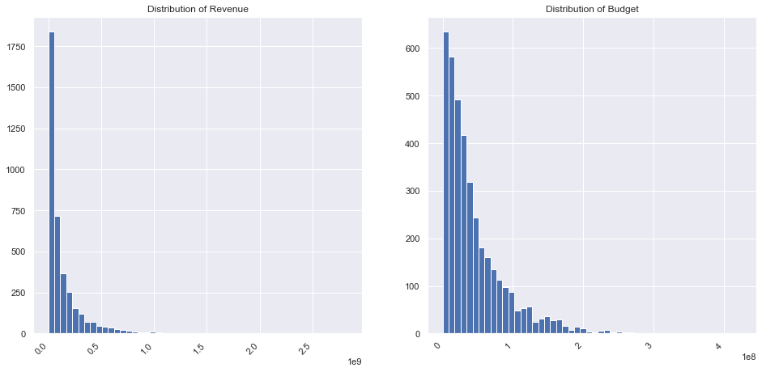

```python
# compare Genres based on number of movies made vs revenue
fig,ax=plt.subplots(ncols=2)
fig.autofmt_xdate(rotation=45)
fig.set_size_inches(16,8)

ax[0].hist('revenue', bins=50, data=df)
ax[1].hist('budget', bins=50, data=df)
ax[0].set(xscale='linear', title='Distribution of Revenue')
ax[1].set(xscale='linear', title='Distribution of Budget')
plt.show()
```

- in general look production companies don't tend to spend more on their movies
- most movies is in the same range of Budget & Revenue

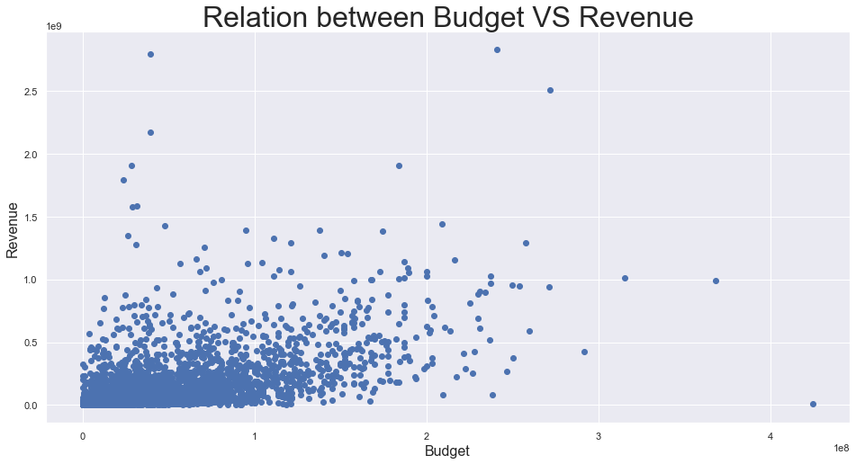

```python
# Continue to explore the data to address your additional research
#   questions. what is the factors of revenue of high popularity levels ?
#   investigate.
plt.figure(figsize=[16, 8])
plt.scatter('budget', 'revenue', data=df)
plt.title('Relation between Budget VS Revenue', fontsize=32)
plt.xlabel('Budget', fontsize=16)
plt.ylabel('Revenue', fontsize=16)
```

### genre vs revenue

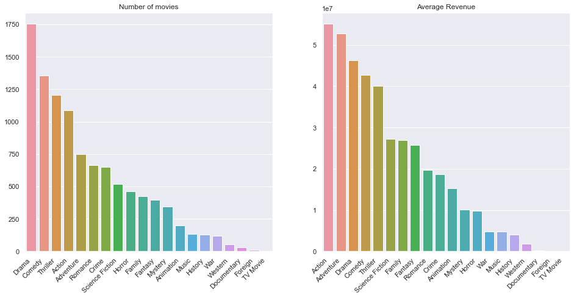

```python
# Claculate number of movies for each Genre
genrecount_df = (df['genres'].str.get_dummies('|'))
data_count = genrecount_df.sum().sort_values(ascending=False)
# calculate average revenue for each genre
genre_avg_df = (df['genres'].str.get_dummies('|')).transpose()
data_avg = (genre_avg_df * df['revenue']).transpose()
avg_revenue = data_avg.mean().sort_values(ascending=False)
# compare Genres based on number of movies made vs revenue
fig,axs=plt.subplots(ncols=2)
fig.autofmt_xdate(rotation=45)
fig.set_size_inches(16,8)
sns.barplot(x=data_count.index,y=data_count.values, ax=axs[0])
sns.barplot(x=avg_revenue.index,y=avg_revenue.values, ax=axs[1])
axs[0].set_title('Number of movies')
axs[1].set_title('Average Revenue')

plt.show()
```

- Most of production companies Made Drama & Comdey types, However Action got high revenue, which means people would prefer that kind of Genre

### vote average vs revenue

```python
def rate_cat(x):
    if x < 5:
        return 'Low'
    elif x >= 5 and x <= 6:
        return 'Medium'
    else:
        return 'High'
df['rate_calss'] = df['vote_average'].apply(rate_cat)
df.head()
```

|  | popularity | cast | director | runtime | genres | vote_average | release_year | budget | revenue | rate_calss |
| --- | --- | --- | --- | --- | --- | --- | --- | --- | --- | --- |
| 0 | 32.985763 | Chris Pratt\|Bryce Dallas Howard\|Irrfan Khan\|Vi... | Colin Trevorrow | 124.0 | Action\|Adventure\|Science Fiction\|Thriller | 6.5 | 2015 | 1.379999e+08 | 1.392446e+09 | High |
| 1 | 28.419936 | Tom Hardy\|Charlize Theron\|Hugh Keays-Byrne\|Nic... | George Miller | 120.0 | Action\|Adventure\|Science Fiction\|Thriller | 7.1 | 2015 | 1.379999e+08 | 3.481613e+08 | High |
| 2 | 13.112507 | Shailene Woodley\|Theo James\|Kate Winslet\|Ansel... | Robert Schwentke | 119.0 | Adventure\|Science Fiction\|Thriller | 6.3 | 2015 | 1.012000e+08 | 2.716190e+08 | High |
| 3 | 11.173104 | Harrison Ford\|Mark Hamill\|Carrie Fisher\|Adam D... | J.J. Abrams | 136.0 | Action\|Adventure\|Science Fiction\|Fantasy | 7.5 | 2015 | 1.839999e+08 | 1.902723e+09 | High |
| 4 | 9.335014 | Vin Diesel\|Paul Walker\|Jason Statham\|Michelle ... | James Wan | 137.0 | Action\|Crime\|Thriller | 7.3 | 2015 | 1.747999e+08 | 1.385749e+09 | High |

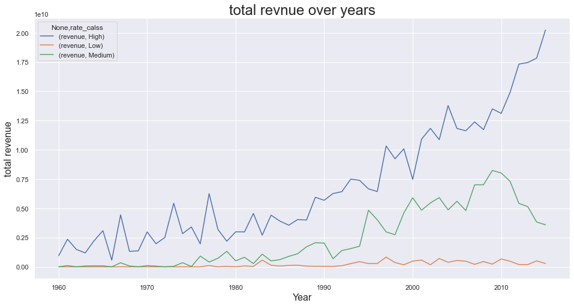

```python
rate_revenue = pd.pivot_table(df, index='release_year', columns=['rate_calss'], values=['revenue'], aggfunc='sum')
rate_revenue.replace(np.nan, 0, inplace=True)
ax = rate_revenue.plot(figsize=[16, 8])
ax.set_title("total revnue over years", fontsize=24)
ax.set_xlabel("Year", fontsize=16)
ax.set_ylabel("total revenue", fontsize=16)
```

- in general look, High revenue movies got high average vote ration
- movies films' industry have imporved in recent years

### Research Question 3 : What is the Charectistic of top movies

```python
top20_movies_revenue = df.sort_values('revenue', ascending=False).head(20)
top20_movies_revenue.head()
```

|  | popularity | cast | director | runtime | genres | vote_average | release_year | budget | revenue | rate_calss |
| --- | --- | --- | --- | --- | --- | --- | --- | --- | --- | --- |
| 1386 | 9.432768 | Sam Worthington\|Zoe Saldana\|Sigourney Weaver\|S... | James Cameron | 162.0 | Action\|Adventure\|Fantasy\|Science Fiction | 7.1 | 2009 | 2.408869e+08 | 2.827124e+09 | High |
| 1329 | 12.037933 | Mark Hamill\|Harrison Ford\|Carrie Fisher\|Peter ... | George Lucas | 121.0 | Adventure\|Action\|Science Fiction | 7.9 | 1977 | 3.957559e+07 | 2.789712e+09 | High |
| 5231 | 4.355219 | Kate Winslet\|Leonardo DiCaprio\|Frances Fisher\|... | James Cameron | 194.0 | Drama\|Romance\|Thriller | 7.3 | 1997 | 2.716921e+08 | 2.506406e+09 | High |
| 10594 | 2.010733 | Linda Blair\|Max von Sydow\|Ellen Burstyn\|Jason ... | William Friedkin | 122.0 | Drama\|Horror\|Thriller | 7.2 | 1973 | 3.928928e+07 | 2.167325e+09 | High |
| 9806 | 2.563191 | Roy Scheider\|Robert Shaw\|Richard Dreyfuss\|Lorr... | Steven Spielberg | 124.0 | Horror\|Thriller\|Adventure | 7.3 | 1975 | 2.836275e+07 | 1.907006e+09 | High |

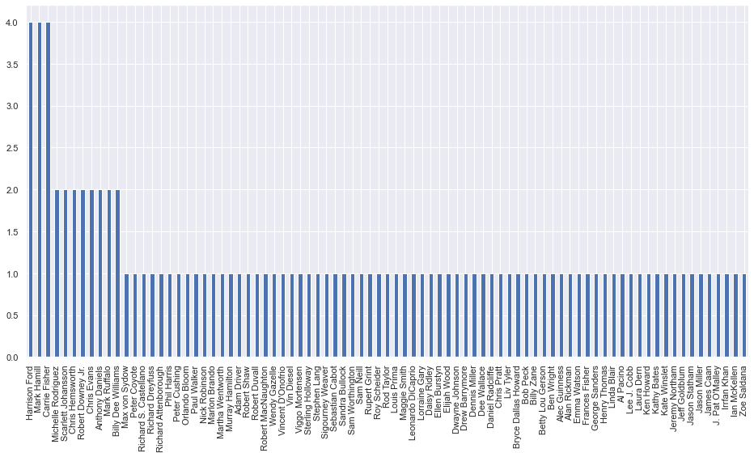

```python
cast_df = top20_movies_revenue['cast'].str.get_dummies('|')
data = cast_df.sum().sort_values(ascending=False)
data.plot(kind='bar', figsize=[16, 8])
```

- (Harrison Ford, Mark Hamill, Carrie Fisher) were most who envoled in top 20 movies

  > It is worth noting that the three are related to each other, they have worked together in many roles (i.e. starwars, a science-fiction movie), also the three are classic actors

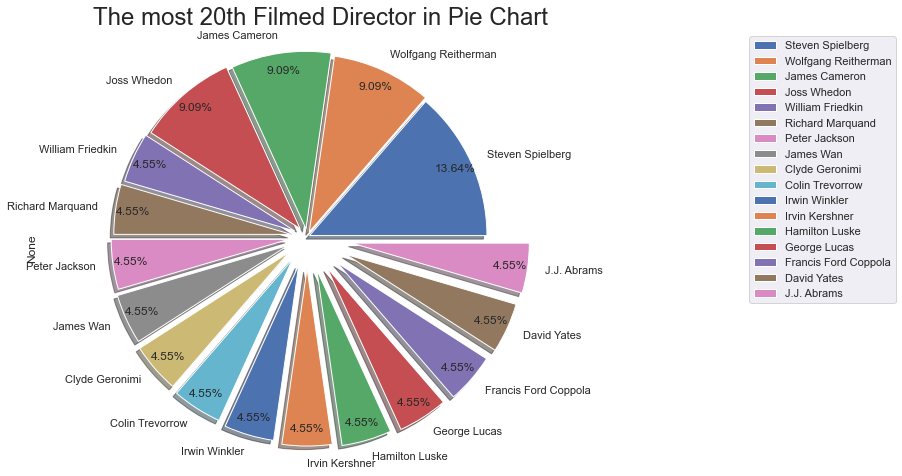

```python
director_df = top20_movies_revenue['director'].str.get_dummies('|')
data = director_df.sum().sort_values(ascending=False)
#setting the explode to adjust the pei chart explode variable to any given size
explode = []
total = 0
for i in range(len(data)):
    total += 0.015
    explode.append(total)

#pie chart for given size and given column
ax = data.plot.pie(autopct='%1.2f%%', shadow=True, startangle=0, pctdistance=0.9, explode=explode, figsize=[10, 8])
plt.title('The most 20th Filmed Director in Pie Chart', fontsize=24)
plt.axis('equal')
plt.legend(loc=9, bbox_to_anchor=(1.4, 1))
```

- Steven Spielberg directed more successfull movies

  > It is worth noting that Steven classic & science fiction movies

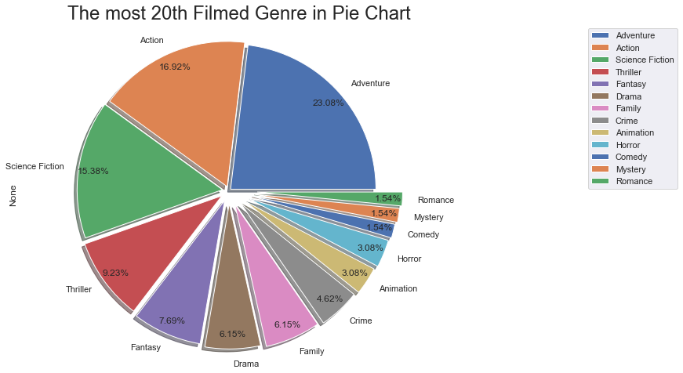

```python
genre_df = top20_movies_revenue['genres'].str.get_dummies('|')
data = genre_df.sum().sort_values(ascending=False)
#setting the explode to adjust the pei chart explode variable to any given size
explode = []
total = 0
for i in range(len(data)):
    total += 0.015
    explode.append(total)

#pie chart for given size and given column
ax = data.plot.pie(autopct='%1.2f%%', shadow=True, startangle=0, pctdistance=0.9, explode=explode, figsize=[10, 8])
plt.title('The most 20th Filmed Genre in Pie Chart', fontsize=24)
plt.axis('equal')
plt.legend(loc=9, bbox_to_anchor=(1.4, 1))
```

- top successful movies are (Adventure, Action, Science Fiction) Genre

### Popularity VS Revenue

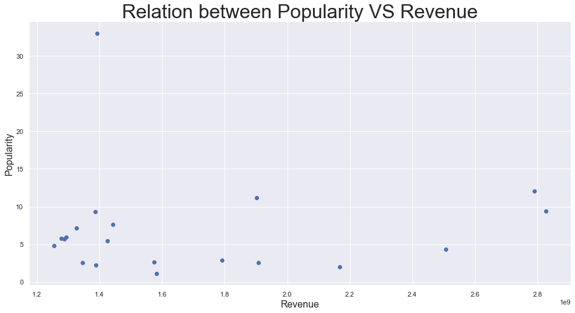

```python
plt.figure(figsize=[16, 8])
plt.scatter('revenue', 'popularity', data=top20_movies_revenue)
plt.title('Relation between Popularity VS Revenue', fontsize=32)
plt.xlabel('Revenue', fontsize=16)
plt.ylabel('Popularity', fontsize=16)
```

> **Tip**: Finally, summarize your findings and the results that have been performed. Make sure that you are clear with regards to the limitations of your exploration. If you haven't done any statistical tests, do not imply any statistical conclusions. And make sure you avoid implying causation from correlation!

> **Tip**: Once you are satisfied with your work, you should save a copy of the report in HTML or PDF form via the **File** > **Download as** submenu. Before exporting your report, check over it to make sure that the flow of the report is complete. You should probably remove all of the "Tip" quotes like this one so that the presentation is as tidy as possible. Congratulations!

## Recommendation

> - i recommend to collect more information for the movies the we have not their budgect & revenue so that we can benefit from it
> - collect more data to have more accurate & usefull insights
> - search for more attribues (i.e. marketing channels details) so that we can discover how much the movie been marketed